[figure not shown]

# Foundations of Streaming Data - The Kafka Consumer

Just as there are several ways to create streaming data, there are at least as many different ways to consume it. Once we have the data, we can visualize it in a plethora of different ways as well. This notebook will walk you through several different exercises, including:

1. Polling Kafka with the "Python client for the Apache Kafka distributed stream processing system"
2. Creating a single visualization of two metrics from a data stream in real time
3. Creating a four-panel visualization of six metrics from a data stream in real time
4. Polling Kafka with PySpark, the "Spark Python API"
5. Polling Kafka with the Confluent Kafka library for Python
6. Streaming to Apache Spark using a port in a Terminal window pane
7. Using Spark Streaming to process files on a file system (**in progress**)

## Exercise 1 - Poll Kafka Using Kafka Python Library

First, we'll do a few imports. Here, we've taken a bunch of functions and moved them into a Python module.

```python
# imports

import consumer_trans_code_behind as ctcb
```

Next, we'll setup our consumer. Everything here is running on the Docker image, so we'll use `localhost` as the server. To start receiving messages from the beginning of the topic, set the `auto_offset_reset` parameter to 'earliest' in the `ctcb.subscribe_and_print()` function. Doing this will produce some strange results, so it's best to just run the code as-is for the time being. Finally, we'll set the `consumer_timeout_ms` parameter to ten seconds, or 10000. This will stop the consumer gracefully if no data has been received after 10 seconds. Note that we most likely wouldn't do this in a production scenario.

```python
brokers = "localhost:9092"
timeout_ms = 10000
topics = ["topic01"]

ctcb.subscribe_and_print(topics, brokers, timeout_ms)
```

```
--------------------------------------------------
auth_id: 17 Authorization Amount: $4.16
--------------------------------------------------
auth_id: 20 Authorization Amount: $258.94
--------------------------------------------------
auth_id: 21 Authorization Amount: $45.91
--------------------------------------------------
auth_id: 22 Authorization Amount: $44.96
--------------------------------------------------
auth_id: 23 Authorization Amount: $43.84
--------------------------------------------------
auth_id: 24 Authorization Amount: $100.00
--------------------------------------------------
auth_id: 25 Authorization Amount: $40.71
--------------------------------------------------
auth_id: 26 Authorization Amount: $13.60
--------------------------------------------------
auth_id: 27 Authorization Amount: $82.21
--------------------------------------------------
auth_id: 28 Authorization Amount: $93.57
--------------------------------------------------
auth_id: 29 Authorization Amount: $29.99
--------------------------------------------------
auth_id: 30 Authorization Amount: $4.52
--------------------------------------------------
auth_id: 31 Authorization Amount: $100.00
--------------------------------------------------
auth_id: 32 Authorization Amount: $94.00
Consumer manually terminated
Consumer is stopped
```

Executing this next cell will do nothing if the producer isn't running. If you need to kick off the producer, [launch the Producer.ipynb notebook from here](http://localhost:8888/tree/foundation) and run through *Streaming Example #1 - Pure Python* until you see messages being produced. Make sure you only have one Producer notebook running at a time though, or you may encounter problems. Then return to this tab and kick off the next cell if you haven't already. You should see messages being received here in the Consumer notebook as well.

```python
import json
# Executing the code in this cell will print each message received
# with a line of 100 dashes between each message

for msg in kc:
    j = json.loads(msg.value)
    print("auth_id:", j["auth_id"], "acct_avl_cash_before_amt:", j["acct_avl_cash_before_amt"])
    # print (msg.value)
    print("-" * 100)
```

[output not shown]

Click the Stop button at the top of the page, or select **Interrupt Kernel** from the Kernel menu before starting the next exercise.

## Exercise 2 - Visualization of Streaming Data - Single Visualization

Next, let's look at the streaming data we just created in a slightly different way. We'll use some modules in matplotlib, widely considered as *the* visualization library for Python, to visualize the streaming data we saw previously. For our first visualization, we'll start by just showing two metrics, the Transaction Number and the Authorization Amount.

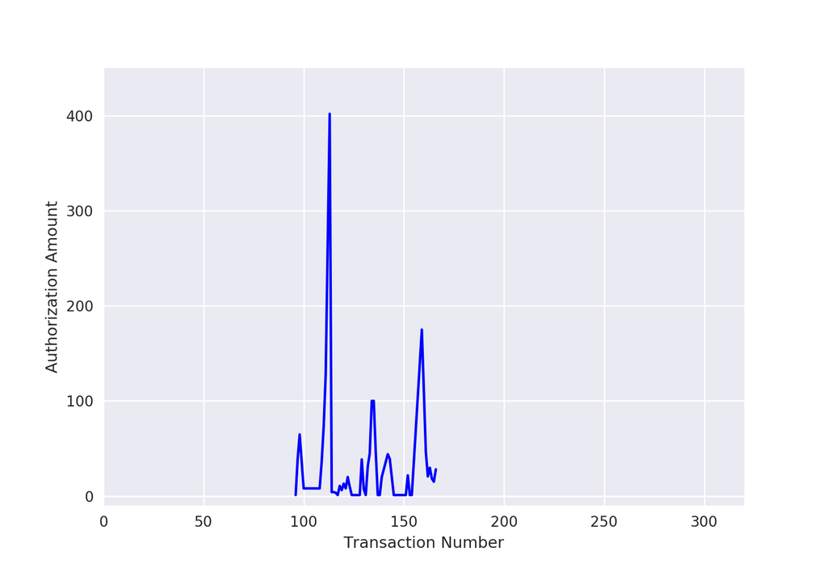

```python
% matplotlib notebook
"""
This is an example modified from the Sinusoidal Decay animation example here:
https://matplotlib.org/examples/animation/animate_decay.html
"""

import seaborn
from kafka import KafkaConsumer
import json

lst_brokers="localhost:9092"
# stop consuming if no messages received for 10 seconds, start from beginning
kc = KafkaConsumer(bootstrap_servers=lst_brokers,
                   # auto_offset_reset='earliest', enable_auto_commit=False,
                  consumer_timeout_ms=10000)
kc.subscribe(topics=["topic01"])

import numpy as np
import matplotlib.pyplot as plt
import matplotlib.animation as animation

import operator


def label_subplot(axis, xlabel, ylabel):
    axis.set_xlabel(xlabel)
    axis.set_ylabel(ylabel)
    return None


def data_gen(t=0):
    for msg in kc:
        t += 1
        j = json.loads(msg.value)

        k = j["authzn_amt"]
        t = j["auth_id"]
        yield [[int(t), float(k)]]


def init():
    ax.set_xlim(0, 10)
    ax.set_ylim(-10, 200)

    del xdata[:]
    del ydata[:]

    line.set_data(xdata, ydata)

    return line,

fig = plt.figure()
ax = fig.add_subplot(1, 1, 1)   # blue line

line, = ax.plot([], [], 'b')

xdata, ydata = [], []

label_subplot(ax, 'Transaction Number', 'Authorization Amount')

def run(data):
    # update the data
    t, y = data[0]

    xdata.append(t)
    ydata.append(y)

    xmin, xmax = ax.get_xlim()
    ymin, ymax = ax.get_ylim()

    if t >= xmax:
        ax.set_xlim(xmin, 2 * xmax)
        ax.figure.canvas.draw()
    if y >= ymax:
        ax.set_ylim(ymin, ymax + 250)
        ax.figure.canvas.draw()

    line.set_data(xdata, ydata)

    plt.pause(0.001)

    return None  # [line, line2],


ani = animation.FuncAnimation(fig=fig, func=run, frames=data_gen, blit=False, interval=10,
                              repeat=False, init_func=init, )
plt.show()

# Writer = animation.writers['ffmpeg']
# writer = Writer(fps=15, metadata=dict(artist='Tech College Streaming Data'), bitrate=1800)
# ani.save('lines.mp4', writer=writer)
```

The visualization above shows the Transaction Number by the Authorization Amount. The x-axis and y-axis scale based on new values that fall outside the limits of the figure's current boundaries. We can do a lot with animations, as illustrated in this next example.

## Exercise 3 - Visualization of Streaming Data - Four-Panel Visualization

To run the code in this next example,

1. Select **Restart & Clear Output** from the Kernel menu in this notebook.
2. Switch over to the Producer notebook. Hit the Stop button in the Producer notebook to stop the production of messages.
3. Hit the Play button in the Producer notebook to start the production of messages from the beginning again.
4. Switch back to this notebook (Consumer) and execute the code in the next cell.

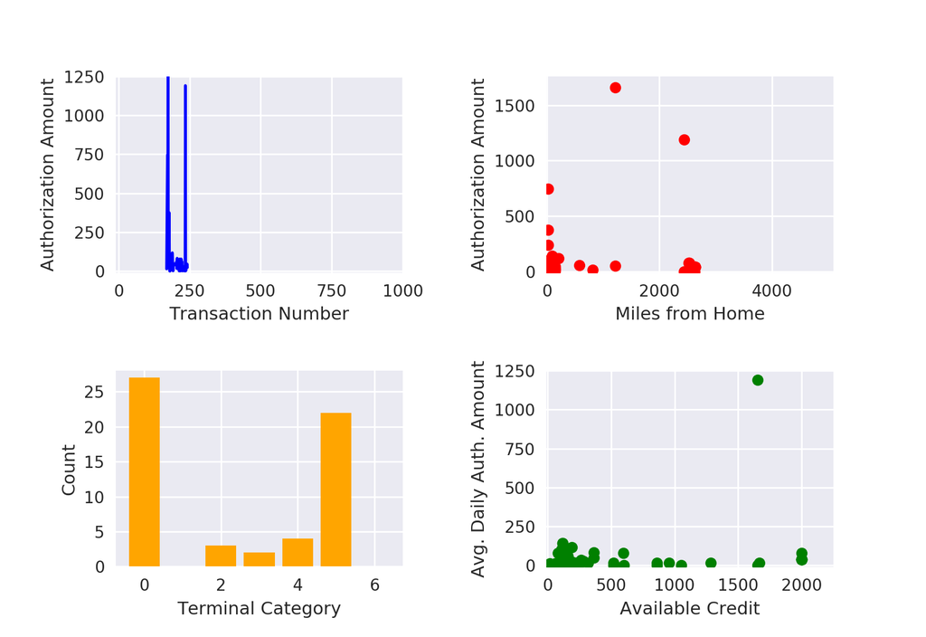

```python
% matplotlib notebook
"""
GRID - All quadrants now have working animations :)

This is an example modified from the Sinusoidal Decay animation example here:
https://matplotlib.org/examples/animation/animate_decay.html

TODO:  The run() function is massive and very tricky to get into a "code-behind"
module, but it would make this block soooo much cleaner if we could get it there.
Main problem is that the run() function "magically" gets the 'data' parameter
passed to it from the yield() statement of the gen_data() function, so it's not
explicitly passed.

"""

import seaborn
from kafka import KafkaConsumer
import json

import numpy as np
import matplotlib.pyplot as plt
import matplotlib.animation as animation

import operator

from setup_figure_code_behind import get_figure_and_axes, gen_data, update_viz

def init():

    # the following sets axes for the line and scatterplots by passing [[xmin, xmax], [ymin, ymax]]
    # for each plot.  Determined it was easier to allow ax3 (bar chart) to figure itself out
    # than try to force it here
    lst_axes = [ax, ax2, ax4]
    lst_xy_limits = [[[0, 10], [-10, 250]]
                     , [[-1, 10], [-10, 250]]
                     , [[-10, 1000], [-10, 1000]]]

    [[axis.set_xlim(xl[0]) for axis in lst_axes] for xl in lst_xy_limits]
    [[axis.set_ylim(xl[1]) for axis in lst_axes] for xl in lst_xy_limits]

    # probably don't need this, but 7 is max and really rare -
    # didn't test 7's coming through
    # ax3.xaxis.set_ticks([0,1,2,3,4,5,6,7,8])

    lst_data = [xdata, ydata, xdata2, ydata2, xdata4, ydata4]
    # can't use list comprehension here, del isn't a function??
    for x in lst_data:
        del x[:]

    term_cat_counts = [0] * 7

    # set data for lines / scatterplots
    line.set_data(xdata, ydata)
    line2.set_data(xdata2, ydata2)
    line4.set_data(xdata4, ydata4)

    # set all rect heights to 0
    for rect, hi in zip(rects, term_cat_counts):
        rect.set_height(int(hi))

    # original example returned a line object, probably don't need to return anything though
    # return line,


def run(data):
    # update the data
    t_num, y = data[0]
    clasfn_cd, _ = data[1]
    m, _ = data[2]
    dist_from_home = data[3][0]
    # Can't seem to get this to work properly
    # t, y, t2, c, m = data

    xdata.append(t_num)
    ydata.append(y)

    xdata2.append(dist_from_home)
    ydata2.append(y)

    term_cat_counts[clasfn_cd] += 1

    xdata4.append(m)
    ydata4.append(y)

    xmin, xmax = ax.get_xlim()
    ymin, ymax = ax.get_ylim()

    xmin2, xmax2 = ax2.get_xlim()
    ymin2, ymax2 = ax2.get_ylim()

    xmin3, xmax3 = ax3.get_xlim()
    ymin3, ymax3 = ax3.get_ylim()

    xmin4, xmax4 = ax4.get_xlim()
    ymin4, ymax4 = ax4.get_ylim()

    # tried using a function for this,
    # but while x-axis updates but y-axis doesn't?  See SO post below.
    # check_axes(axis=ax, x=t, y=y, scale_by_x=2, scale_op_x="*", scale_by_y="250", scale_op_y="+")
    # https://stackoverflow.com/questions/10090426/matplotlib-y-axis-limits-not-updating-after-setting-x-axis-limits
    if t_num >= xmax:
        # ax.set_xlim(xmin, 2 * xmax)
        ax.set_xlim(xmin + 2, t_num + 2)
        ax.figure.canvas.draw()
    if y >= ymax:
        ax.set_ylim(ymin, ymax + 250)
        ax.figure.canvas.draw()

    if dist_from_home >= xmax2:
        ax2.set_xlim(xmin2, 2 * dist_from_home)
        ax2.figure.canvas.draw()
    if y >= ymax2:
        ax2.set_ylim(ymin2, y + 100)
        ax2.figure.canvas.draw()

    if clasfn_cd >= xmax3:
        ax3.set_xlim(xmin3, clasfn_cd + 2)
        ax3.figure.canvas.draw()
    elif clasfn_cd < xmin3:
        ax3.set_xlim(clasfn_cd - 1, xmax3)
        ax3.figure.canvas.draw()

    if m >= xmax4:
        ax4.set_xlim(xmin4, xmax4 + 250)
        ax4.figure.canvas.draw()
    if y >= ymax4:
        ax4.set_ylim(ymin4, ymax4 + 250)
        ax4.figure.canvas.draw()

    line.set_data(xdata, ydata)
    line2.set_data(xdata2, ydata)  # changed this from ydata2, it's all the same metric
    line4.set_data(xdata4, ydata4)

    if max(term_cat_counts) >= ymax3:
        ax3.set_ylim(ymin3, 1 + max(term_cat_counts))
        ax3.figure.canvas.draw()

    for rect, height in zip(rects, term_cat_counts):
        rect.set_height(height)
    ax3.figure.canvas.draw()

    plt.pause(0.001)

    return None  # [line, line2],

# Everything down here seems to need to be in a more "global" kind of scope
# for the animation to work properly, which is why it's tricky to get code
# into a module

lst_brokers="localhost:9092"
# stop consuming if no messages received for 10 seconds, start from wherever
# the producer is currently (not at the beginning, that causes issues)

kc = KafkaConsumer(bootstrap_servers=lst_brokers,
                   # auto_offset_reset='earliest', enable_auto_commit=False,
                  consumer_timeout_ms=10000)
kc.subscribe(topics=["topic01"])

# setup the figure and axes for the four-panel visualization
fig, ax, ax2, ax3, ax4 = get_figure_and_axes()

# note the comma after the "line" objects, this is necessary as ax.plot()
# returns more than one thing, I'm guessing

line, = ax.plot([], [], 'b')
line2, = ax2.plot([], [], 'ro')
rects = ax3.bar(range(0, 7), [0] * 7, align='center', color="orange")
line4, = ax4.plot([], [], 'go')

xdata, ydata = [], []
xdata2, ydata2 = [], []
term_cat_counts = [0] * 7
xdata4, ydata4 = [], []

fig.subplots_adjust(hspace=0.5)
fig.subplots_adjust(wspace=0.5)

ani = animation.FuncAnimation(fig=fig, func=run, frames=gen_data(kc), blit=True, interval=10,
                              repeat=False, init_func=init, )

plt.show()
```

Here, we have our original visualization in the upper left-hand quadrant, along with three other visualizations. We are viewing aggregated data for streaming of six different metrics:

- Transaction Number
- Authorization Amount
- Miles from Home
- Terminal Category
- Average Daily Authorization Amount
- Available Credit

But what if we want to do more than just display the data in the messages received? We may want to run a machine learning algorithm against specific data elements the stream, perform some sort of aggregations, or even redirect things to another Kafka topic. We can easily do all that as well, we just need a little help from some other libraries.

As with most things, there's more than one way to approach a streaming data challenge. Another tool in the box is Spark Streaming. Next, we'll look at consuming a Kafka topic using `KafkaUtils` from `pyspark.streaming.kafka`

## Exercise 4 - Poll Kafka Using pyspark.streaming.kafka

Once again, we'll start with a few imports. This time, most of what we'll need is in the Spark Python API, also known as [PySpark](https://spark.apache.org/docs/latest/api/python/index.html).

If you haven't already, select the **Restart & Clear Output** option from the Kernel menu above. Then run the code in the next cell to import the PySpark modules.

```python
from __future__ import print_function

import sys

from pyspark.sql import SparkSession
from pyspark import SparkContext, SQLContext #, SparkConf
from pyspark.streaming import StreamingContext
from pyspark.streaming.kafka import KafkaUtils
```

First, we'll initialize a SparkContext and a StreamingContext, and set variables for Zookeeper and the topic name.

```python
try:
    sc = SparkContext(appName="PythonStreamingKafkaWordCount")
except ValueError:
    print("Warning - SparkContext already initialized")

# Streaming context will report every 5 seconds
ssc = StreamingContext(sc, 5)
```

Next, we'll set `localhost` as the server and 2181 as the port number for the Zookeeper quorum, and we'll create and publish to a new topic, *spark_kafka_topic01*:

```python
zkQuorum = "localhost:2181"
topic = "spark_kafka_topic01"
```

Let's create a transformed discretized stream, or TransformedDStream, for Spark Streaming, and connect it to the topic we defined above:

```python
kvs = KafkaUtils.createStream(ssc, zkQuorum, "spark-streaming-consumer", {topic: 1})
```

Next, we'll create the ubiqutious "word count" big data script, but with a twist. This will output a list of up to 20 words and their counts, but because it's using the Spark Streaming Context, it will report only counts of words it has received every five seconds. Essentially, all previous information is "forgotten" each time it reports. We've sorted this list so you'll see the most frequently-used words at the top of the list.

After executing the code in the next cell, you should see a timestamp produced approximately every five seconds. Once you start streaming data to the topic (in the next step), you'll see the aggregated word count below the timestamps.

```python
# for each message, grab its value
lines = kvs.map(lambda x: x[1])

# split the line into its words, counting each word
counts = lines.flatMap(lambda line: line.split(" ")) \
    .map(lambda word: (word, 1)) \
    .reduceByKey(lambda a, b: a+b)

# finally, use the pprint() method of the DStream object to print up to 20 of the words
# received in the previous five seconds
counts_sorted = counts.transform((lambda x:x.sortBy(lambda y:( -y[1])))) # .pprint(20)
counts_sorted.pprint(20)

# Start the StreamingContext and wait indefinitely for it to terminate
ssc.start()
ssc.awaitTermination()
```

Return to a command prompt and enter this at the command line:

`$KAFKA_HOME/bin/kafka-console-producer.sh --broker-list localhost:9092 --topic spark_kafka_topic01`

The above command starts a shell script that will send each line of text you enter into the Terminal window to the topic called `spark_kafka_topic01`. If you copy and paste a few paragraphs of text (for instance, from [this Pulse article by Brent Foster, Dean of Data](https://pulse.kdc.capitalone.com/community/resources/capital-one-university/tech-college/blog/2017/06/17/crowdsourcing)) into the same Terminal window and hit your Enter key, you should be able to see the results in the notebook window just above this cell. Note that you may need to scroll down in the window to see the most recent results.

Once you're ready to move on, select the **Restart & Clear Output** option from the Kernel menu above. Return to your terminal window and hit `Ctrl-c` a few times to exit the Spark Streaming script and return to the command prompt.

## Exercise 5 - Polling Kafka with the Confluent Kafka library for Python

Next, let's repeat the first exercise, but this time, we'll use the Kafka library from Confluent. [Confluent](https://www.confluent.io/) is a company run by Jay Krebs, who led the team that originall created Kafka while he worked at LinkedIn. This library has much of the same functionality as the Kafka-python library we used earlier, as we'll see below.

```python
from confluent_kafka import Consumer, KafkaError
import json

lst_brokers = "localhost:9092"
topic = "topic01"

c = Consumer({'bootstrap.servers': lst_brokers, 'group.id': 'mygroup',
            'default.topic.config': {'auto.offset.reset': 'largest'}})
c.subscribe([topic])
running = True
while running:
    msg = c.poll()
    if not msg.error():
        try:
            j = json.loads(msg.value().decode('utf-8'))
            print("auth_id:", j["auth_id"], "acct_avl_cash_before_amt:", j["acct_avl_cash_before_amt"])
            print("-" * 100)
        except Exception as e:
            print(str(e))
    elif msg.error().code() != KafkaError._PARTITION_EOF:
        print(msg.error())
        running = False
c.close()
```

One not insignificant detail is that the defaults between the kafka-python and confluent-kafka-python implementations have different defaults. In the latter, we must pass the `auto.offset.reset` parameter in the `default.topic.config` section of the consumer creation code and set it to `largest` to mimic the default functionality of the kafka-python implementation. Note that while this is a non-production-ready example, the concept of default values is something that should always be considered when implementing a solution.

Also note that with the confluent-kafka-python implementation, there may be a significant delay between when the consumer is created and when the first messages are displayed.

## Exercise 6 - Pure Spark Streaming from a Network Socket

Next, we'll return to the console to run a tmux session. `tmux` is a window multiplexer for the *NIX environment. We've developed a script to setup the environment as a split pane window as shown in the next screenshot. In your Terminal window, enter the following commands:

```
cd /home/streamuser/host_documents/foundation
bash run_tmux.sh
```

Please note that we're running this with `bash` and not with `sh` as with other exercises in this notebook. You'll see the following message:

> This script will start a window multiplexer called 'tmux' with two Terminal panes side by side. The pane on the left runs the Netcat program and opens port 9999. Any text typed into this pane will be sent to port 9999. At the same time, the right pane runs a network wordcount Python script listening on port 9999. The right window will display a timestamp every five seconds, along with an aggregate, non-accumulating word count of words it has received from port 9999 in the last five seconds.

> About five seconds after you enter the tmux environment, hit Ctrl-b, then the 'o' key to swap focus to the left-hand pane and start entering text. Note that you will need to hit the Enter key to send the text to port 9999.

> To exit this environment, hit Ctrl-c twice while the left pane has focus.

[figure not shown]

In the above screenshot, the appearance of the cursor at the bottom of the right-hand pane indicates that the pane is "active."

Only one of these Terminal sessions is "active" at a time. You can switch to make the other active with:

`Ctrl-b o`

That's Control+b, then *just* the 'o' key. You'll know it's active if you see your cursor in the pane.

A full discussion of tmux is outside the scope of this courrse, but if you're interested, here's a [tmux cheat sheet](https://gist.github.com/MohamedAlaa/2961058). Note that you always enter `Ctrl-b` to enter command mode.

Now that the left pane is active, paste something in from your clipboard and keep your eye on the right pane (might we suggest [yet another awesome blog post from Data Dean, Brent Foster?](https://pulse.kdc.capitalone.com/people/HVT558/blog)). Every five seconds, the Spark Streaming application will report the (non-cumulative) count of the 20 most frequently-counted words it has received (this can be configured by changing the `int_print_words` variable in the `/home/streamuser/host_documents/foundation/network_wordcount.py` file).

At this point, you may be curious to see what the Spark job looks like. If you click [this link](http://localhost:4040/jobs/) you'll see the Spark Streaming job, as well as a history of any other completed jobs since you started the Docker image. If you click on the Streaming tab along the top, you'll see several graphs detailing metrics like Input Rate, Scheduling Delay, Processing Time, and Total Delay. We'll be covering these more in future sections of this learning path.

## Exercise 7 - Word Count - Spark Streaming with a File

You can open the file and take a look at the code to verify that it's indeed using Spark streaming to accomplish this. We could have easily run a regular Spark job to accomplish this task, so let's see the real power of Spark streaming by opening two Terminal windows side-by-side in tmux, pasting text into one, and watching Spark Streaming aggregate this data every five seconds.

## Exercise 8 - Stream a Directory of Files to Spark Streaming

```python
%matplotlib notebook
%config InlineBackend.figure_format = 'retina'

# Currently under consideration, do we want to stream one or more files and do a wordcount?
# If so, it might be better to move this example earlier in the notebook
```